# Machine learning

Published

July 13, 2024

## Goal

In this lab we will learn the basics of Machine Learning (ML). We will focus on supervised learning. We will start with the simple idea of linear discrimination, and then move on to important concepts in ML: cross-validation, overfitting and variance-bias trade-off.

## Packages

Install packages.

```r
pkgs_needed = c("MASS","ExperimentHub", "tidyverse","glmnet", "RColorBrewer","caret")
letsinstall = setdiff(pkgs_needed, installed.packages())
if (length(letsinstall) > 0) {
  for (pkg in letsinstall) {
    BiocManager::install(pkg, dependencies = TRUE)
  }
}
```

Load packages.

```r
library(tidyverse)
library(MASS)
library(ExperimentHub)
library(glmnet)
library(RColorBrewer)
library(caret)
```

## Diabetes data set

The `diabetes` dataset presents three different groups of diabetes patients and five clinical variables measured on them. We will try to use those measured variables to predict the group of a patient.

```r
# load data
diabetes = read_csv(
  url("http://web.stanford.edu/class/bios221/data/diabetes.csv"),
  col_names = TRUE
)
# if download fails with timeout error, try increasing it
# options(timeout = 1000)
diabetes
```

```
# A tibble: 144 × 7
      id relwt glufast glutest steady insulin group
   <dbl> <dbl>   <dbl>   <dbl>  <dbl>   <dbl> <dbl>
 1     1  0.81      80     356    124      55     3
 2     3  0.94     105     319    143     105     3
 3     5  1         90     323    240     143     3
 4     7  0.91     100     350    221     119     3
 5     9  0.99      97     379    142      98     3
 6    11  0.9       91     353    221      53     3
 7    13  0.96      78     290    136     142     3
 8    15  0.74      86     312    208      68     3
 9    17  1.1       90     364    152      76     3
10    19  0.83      85     296    116      60     3
# ℹ 134 more rows
```

```r
# convert group to factor
diabetes$group <- factor(diabetes$group)
```

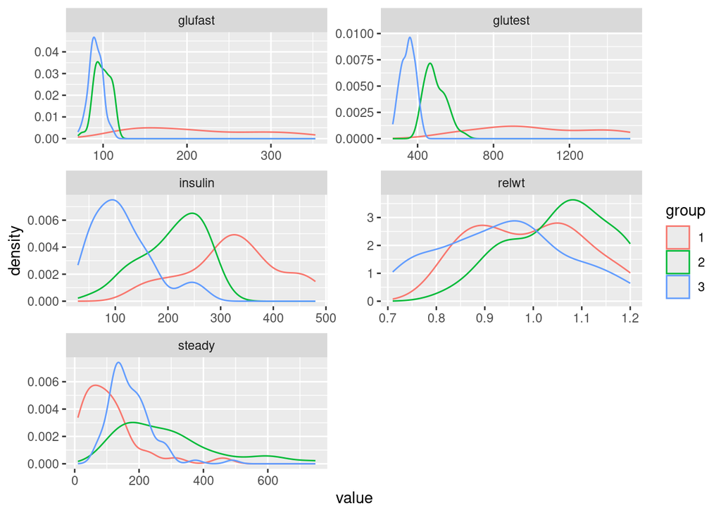

```r
# transform data to long format
diabetes.long = pivot_longer(
  data = diabetes,
  cols = -c(id, group),
  names_to = "variable",
  values_to = "value"
)

# plot distribution of different variables in the data
ggplot(data = diabetes.long, mapping = aes(x = value, col = group)) +
  geom_density() + facet_wrap( ~ variable, ncol = 2, scales = "free")
```

We see already from the one-dimensional distributions that some of the individual variables could potentially predict which group a patient is more likely to belong to.

**Question**

Which of the variables seem to be most informative for distinguishing the groups?

```r
cat("Insulin")
```

```
Insulin
```

Our goal will be to combine variables to get the more accurate predictions.

## Linear discrimination analysis (LDA)

We start with one of the simplest possible discrimination problems.

We will use two variables, `insulin` and `glutest`, to predict the `group`. Our aim is to partition the 2D plane defined by these variables into classes, using class boundaries that are straight lines.

**Question**

It’s always a good idea to first visualize the data. Look at how `insulin` and `glutest` are distributed relative to each other by plotting the scatterplot of the two variables and colouring the points by the group.

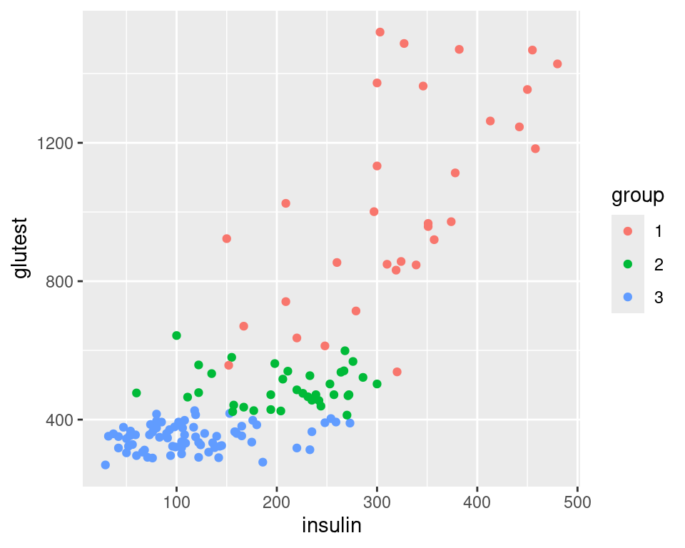

```r
ggdb <- ggplot(diabetes, aes(x = insulin, y = glutest, colour = group)) +
         geom_point()
ggdb
```

We’ll start with a method called linear discriminant analysis (LDA). This method is a foundation stone of classification, many of the more complicated (and sometimes more powerful) algorithms are really just generalizations of LDA.

To calculate LDA, we will use the `lda` function from the `MASS` package. One way to run this function (and many other models in R) is using the formula notation. To read more about LDA and formula format, check `?lda` and `?formula`.

In the simple form, a formula can look like this:

`response ~ predictor1 + predictor2 + ... + predictorn`

Here `response` is the variable we want to predict, and `predictor1`, `predictor2`, etc. are the variables we use to make the prediction.

Response and predictors can be vectors of data used in the model.  
Alternatively, if data argument is specified, they can be (unquoted!) column names of the data that contain the response and predictor values.  
Yet another alternative is to fit `lda` by providing as parameter `x` a data.frame of predictor variables (with observations as rows and variables as columns), and as parameter `groupping` a corresponding factor of response variables i.e. groups.

Below we show these different ways in which we can fit the LDA model using diabetes data. All the three lines of code are equivalent.

```r
# three ways to fit LDA model:
diabetes_lda <- lda(diabetes$group ~ diabetes$insulin + diabetes$glutest)
diabetes_lda <- lda(group ~ insulin + glutest, data = diabetes)
diabetes_lda <- lda(x = diabetes[, c("insulin", "glutest")], grouping = diabetes$group)

# inspect the model
diabetes_lda
```

```
Call:
lda(diabetes[, c("insulin", "glutest")], grouping = diabetes$group)

Prior probabilities of groups:
        1         2         3
0.2222222 0.2500000 0.5277778

Group means:
   insulin   glutest
1 320.9375 1027.3750
2 208.9722  493.9444
3 114.0000  349.9737

Coefficients of linear discriminants:
                 LD1         LD2
insulin -0.004463900 -0.01591192
glutest -0.005784238  0.00480830

Proportion of trace:
   LD1    LD2
0.9677 0.0323
```

In the shown model summary:  
- prior probabilities are calculated as the fraction of samples from every group  
- group means are the means of the variables for each group  
- coefficients are the coefficients of the linear model  
- proportion of trace are the proportions of inter-group variance explained

We can then use the model for prediction.

```r
# predictions from model
ghat <- predict(diabetes_lda)$class

# contingency table
table(predicted = ghat, truth = diabetes$group)
```

```
         truth
predicted  1  2  3
        1 25  0  0
        2  6 24  6
        3  1 12 70
```

```r
# prediction error
mean(ghat != diabetes$group)
```

```
[1] 0.1736111
```

Now, let’s visualize the LDA result. We are going to plot the prediction regions for each of the three groups. We do this by creating a grid of points and using our prediction rule on each of them (note the parameter `newdata` in the `predict()` function now) On top of this, we also plot the class centers. Assembling this visualization requires us to write a bit of code, but don’t worry too much if you don’t understand it - we do this just to illustrate the concepts.

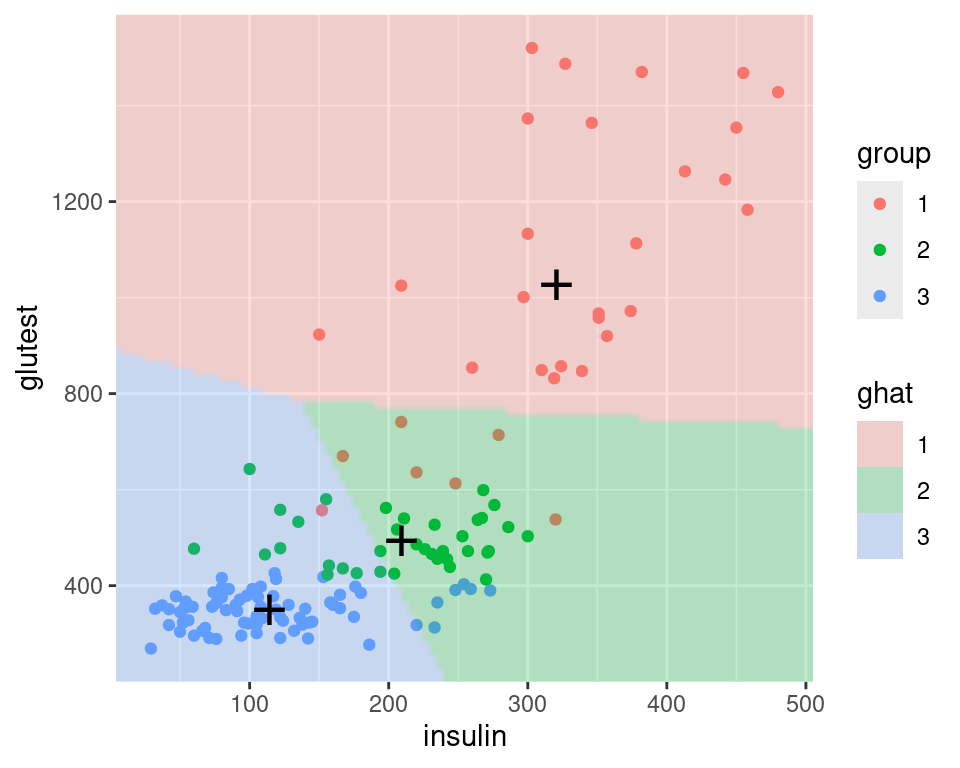

```r
# helper function to make 1D grid
make1Dgrid <- function(x) {
  # extend the range of x by small fraction on both sides
  rg <- grDevices::extendrange(x)
  # generate 100 sequential values within extended range of x
  seq(from = rg[1], to = rg[2], length.out = 100)
}

# get all combinations of insulin and glutest in the range of the data
diabetes_grid <- with(
  diabetes,
  expand.grid(
    insulin = make1Dgrid(insulin),
    glutest = make1Dgrid(glutest)
  )
)

# predictions for the grid values
diabetes_grid$ghat <- predict(diabetes_lda, newdata = diabetes_grid)$class

# group centers
centers <- diabetes_lda$means

# plotting on top of the diabetes data scatterplot we generated before
ggdb +
  # we add prediction regions plotted as raster image on top of original points
  geom_raster(
    data = diabetes_grid,
    mapping = aes(x = insulin, y = glutest, fill = ghat),
    inherit.aes = FALSE, alpha = 0.25, interpolate = TRUE
  ) +
  # we add centers as + points
  geom_point(
    data = as_tibble(centers),
    mapping = aes(x = insulin, y = glutest),
    inherit.aes = FALSE, pch = "+", size = 8
  ) +
  scale_x_continuous(expand = c(0, 0)) +
  scale_y_continuous(expand = c(0, 0))
```

**Question**

Instead of trying to predict with 2 variables, fit LDA model with all 5 variables.  
Get predictions using this new model.  
Get the confusion table for predictions, and calculate the prediction error.

```r
# fit the model
diabetes_lda5 <- lda(group ~ relwt + glufast + glutest + steady + insulin, data = diabetes)

# predicitons
ghat5 <- predict(diabetes_lda5)$class

# confusion table
table(ghat5, diabetes$group)
```

```
ghat5  1  2  3
    1 26  0  0
    2  5 31  3
    3  1  5 73
```

```r
# error
mean(ghat5 != diabetes$group)
```

```
[1] 0.09722222
```

How did the prediction error change compared to the model with only 2 variables?

It decreased - the prediction error is almost half compared to what we got with only the insulin and glutest variables.

Based on this, can you tell if the classifier trained with 5 variables is better than the one trained with only 2?

No, because the errors are computed on the same data that we use for model training, so the model with lower error might actually be overfitting the data.

## Cross-validation

Previously we were looking at predictions and classification error on the same data that we used for training the model. This is not the most correct approach, as the model will always perform better on the training data than on the new, unseen data. In extreme cases, the model could fail to learn the trends underlying the data, but instead it simply memorizes the values that it is trained on - this is called overfitting, and is something we want to avoid.

To get a good idea if the model learns well, we need to estimate its performance on new data it hasn’t seen before. The most simple way to do this, we would to use a fraction of data only for training, and a fraction only for testing. However, by splitting the data only once, our results can be quite affected by how the split happens to fall, especcially if we don’t have many observations. Another way to deal with this would be to perform cross validation (CV).

Below we will look at one version of CV, called leave-one-out cross-validation (LOOCV). In LOOCV, we fit the whole model without one data point and then we predict the label of the left-out point. We know the true label of that data point, and the learning algorithm does not, hence we can get a reasonable estimate of the algorithm’s performance on this “new” data. Then, this process is repeated for each data point separately, and the average error is calculated.

**Question**

Let’s write a function that fits `lda` model with LOOCV. In the code below, the parameters of the function are described after `@param` keywords, and the `@value` describes what the function should output. Complete the function template provided (replace `...` with code).

```r
#' A function to perform LOOCV
#'
#' @param x data.frame of predictor variables (rows are observations, columns are variables)
#' @param grouping factor, response variable (length should be the same as nrow(x))
#'
#' @value vector with mean training and test error
#'
estimate_mcl_loocv = function(x, grouping) {
  # iterate over observations
  vapply(seq_len(nrow(x)), function(i) {
    # fit a model with i-th observation left-out
    fit  = lda(x = x[-i, ], grouping = grouping[-i])
    # predict on the training data
    ptrn = predict(fit, newdata = x[-i,, drop = FALSE])$class
    # predict on the test data i,e, left-out i-th observation
    ptst = predict(fit, newdata = x[ i,, drop = FALSE])$class
    # return training and test errors
    c(
      train = mean(ptrn != grouping[-i]),
      test = (ptst != grouping[i])
    )
  }, FUN.VALUE = numeric(2)) %>% rowMeans
}
```

**Question**

Now compare again the errors for model trained with only `insulin` and `glutest`, and the model trained with all variables. Which model is better?

```r
estimate_mcl_loocv(x = diabetes[, c("insulin", "glutest")], grouping = diabetes$group)
```

```
    train      test
0.1774476 0.1875000
```

```r
estimate_mcl_loocv(x = diabetes[, c("insulin", "glutest", "glufast", "relwt", "steady")], grouping = diabetes$group)
```

```
     train       test
0.09931041 0.11111111
```

Both the training and the test error are lower for the model with 5 variables

In the section below you will also see CV used to pick a parameter for LASSO-logistic regression.

## Metagenome data set

```r
library(ExperimentHub)

# get experiments
eh = ExperimentHub()
# if you encounter problem, try running
# eh = ExperimentHub(localHub = TRUE)

# selected experiment
zeller = eh[["EH361"]]

# inspect ExpressionSet object
zeller
```

```
ExpressionSet (storageMode: lockedEnvironment)
assayData: 1505 features, 156 samples
  element names: exprs
protocolData: none
phenoData
  sampleNames: CCIS00146684ST-4-0 CCIS00281083ST-3-0 ...
    CCIS98832363ST-4-0 (156 total)
  varLabels: subjectID age ... number_reads (15 total)
  varMetadata: labelDescription
featureData: none
experimentData: use 'experimentData(object)'
  pubMedIds: 25432777
Annotation:
```

`ExpressionSet` contains gene expression data, together with the samples and features information. Expression data can be accessed with `exprs()`, sample information with `pData()` (phenotypic data), and feature information with the `fData()` accessors.

Check sample information for `zeller` dataset.

```r
head(pData(zeller))
```

```
                   subjectID age gender bmi country disease tnm_stage
CCIS00146684ST-4-0    FR-726  72 female  25  france       n      <NA>
CCIS00281083ST-3-0    FR-060  53   male  32  france       n      <NA>
CCIS02124300ST-4-0    FR-568  35   male  23  france       n      <NA>
CCIS02379307ST-4-0    FR-828  67   male  28  france  cancer    t1n0m0
CCIS02856720ST-4-0    FR-027  74   male  27  france       n      <NA>
CCIS03473770ST-4-0    FR-192  29   male  24  france       n      <NA>
                   ajcc_stage localization     fobt wif-1_gene_methylation_test
CCIS00146684ST-4-0       <NA>         <NA> negative                    negative
CCIS00281083ST-3-0       <NA>         <NA> negative                    negative
CCIS02124300ST-4-0       <NA>         <NA> negative                    negative
CCIS02379307ST-4-0          i           rc positive                    positive
CCIS02856720ST-4-0       <NA>         <NA> positive                    negative
CCIS03473770ST-4-0       <NA>         <NA> negative                    negative
                     group bodysite ethnicity number_reads
CCIS00146684ST-4-0 control    stool     white     76003628
CCIS00281083ST-3-0 control    stool     white     47190574
CCIS02124300ST-4-0 control    stool     white     87631061
CCIS02379307ST-4-0     crc    stool     white     10574044
CCIS02856720ST-4-0 control    stool     white     73567419
CCIS03473770ST-4-0 control    stool     white     46217866
```

```r
tail(pData(zeller))
```

```
                   subjectID age gender bmi country       disease tnm_stage
CCIS95097901ST-4-0    FR-696  52   male  24  france             n      <NA>
CCIS95409808ST-4-0    FR-152  63 female  21  france             n      <NA>
CCIS96387239ST-4-0    FR-626  66   male  20  france small_adenoma      <NA>
CCIS98482370ST-3-0    FR-052  53 female  30  france             n      <NA>
CCIS98512455ST-4-0    FR-459  63   male  29  france        cancer    t4n1m1
CCIS98832363ST-4-0    FR-552  55 female  25  france        cancer    t3n1m0
                   ajcc_stage localization     fobt wif-1_gene_methylation_test
CCIS95097901ST-4-0       <NA>         <NA> negative                    negative
CCIS95409808ST-4-0       <NA>         <NA> negative                    negative
CCIS96387239ST-4-0       <NA>           lc negative                    negative
CCIS98482370ST-3-0       <NA>         <NA> negative                    negative
CCIS98512455ST-4-0         iv           rc negative                    negative
CCIS98832363ST-4-0        iii           lc positive                    negative
                     group bodysite ethnicity number_reads
CCIS95097901ST-4-0 control    stool     white     51567166
CCIS95409808ST-4-0 control    stool     white     66865743
CCIS96387239ST-4-0 control    stool     white     34953403
CCIS98482370ST-3-0 control    stool     white     45190917
CCIS98512455ST-4-0     crc    stool     white     46052438
CCIS98832363ST-4-0     crc    stool     white     69793122
```

Columns of the annotations can be accessed directly by their names, e.g. `zeller$disease`.

```r
table(zeller$disease)
```

```
       cancer large_adenoma             n small_adenoma
           53            15            61            27
```

For the following exercises, we will focus only on the normal (`n`) and `cancer` samples, so we will now also sample the `ExpressionSet` object to include only these samples.

```r
zellerNC <- zeller[, zeller$disease %in% c("n", "cancer")]
```

Notice that feature information in this dataset (`fData(zellerNC)`) is empty. We only have feature names in the expression data.

```r
head(rownames(zellerNC))
```

```
[1] "k__Bacteria"                    "k__Viruses"
[3] "k__Bacteria|p__Firmicutes"      "k__Bacteria|p__Bacteroidetes"
[5] "k__Bacteria|p__Actinobacteria"  "k__Bacteria|p__Verrucomicrobia"
```

```r
tail(rownames(zellerNC))
```

```
[1] "k__Viruses|p__Viruses_noname|c__Viruses_noname|o__Viruses_noname|f__Baculoviridae"
[2] "k__Viruses|p__Viruses_noname|c__Viruses_noname|o__Viruses_noname|f__Baculoviridae|g__Alphabaculovirus"
[3] "k__Viruses|p__Viruses_noname|c__Viruses_noname|o__Viruses_noname|f__Baculoviridae|g__Alphabaculovirus|s__Bombyx_mori_nucleopolyhedrovirus"
[4] "k__Bacteria|p__Proteobacteria|c__Deltaproteobacteria|o__Desulfovibrionales|f__Desulfovibrionaceae|g__Desulfovibrio|s__Desulfovibrio_termitidis"
[5] "k__Viruses|p__Viruses_noname|c__Viruses_noname|o__Viruses_noname|f__Baculoviridae|g__Alphabaculovirus|s__Bombyx_mori_nucleopolyhedrovirus|t__Bombyx_mori_nucleopolyhedrovirus_unclassified"
[6] "k__Bacteria|p__Proteobacteria|c__Deltaproteobacteria|o__Desulfovibrionales|f__Desulfovibrionaceae|g__Desulfovibrio|s__Desulfovibrio_termitidis|t__GCF_000504305"
```

As you can see, the features are a mixture of abundance quantifications at different taxonomic levels, from **k**ingdom over **p**hylum to **s**pecies. We could select only some of these, but here we continue with all of them.

Next, let’s look at the distribution of some of the features. Here, we show an arbitrary choice of features; in practice, it is helpful to scroll through many such plots quickly to get an impression.

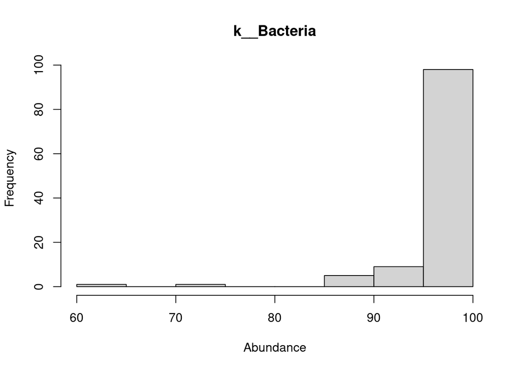

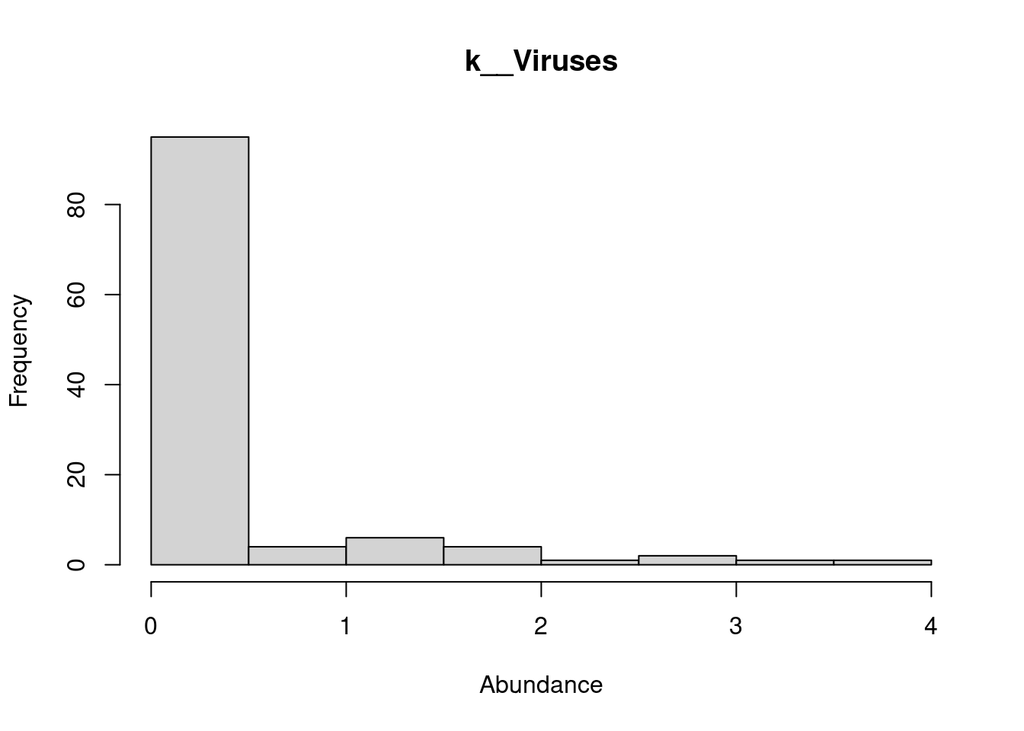

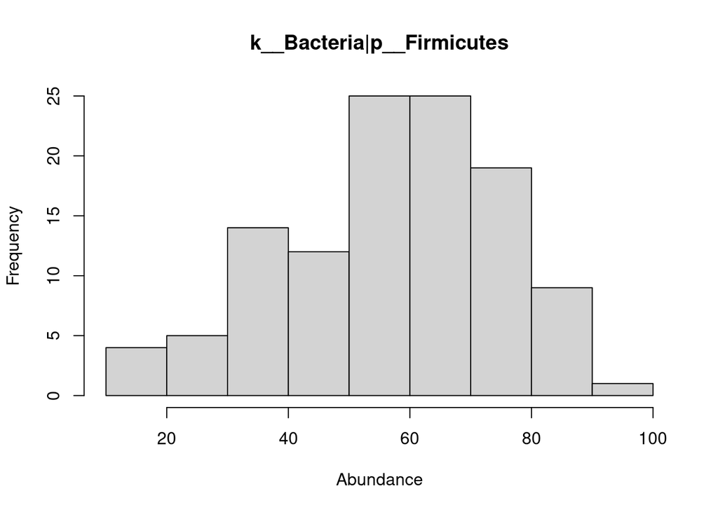

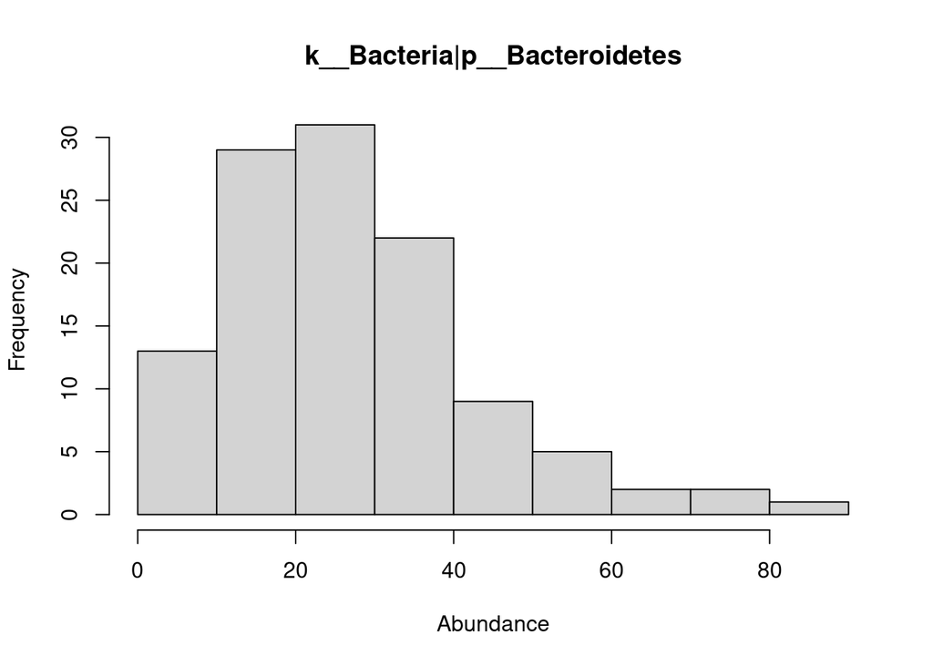

```r
# convert to data.frame
tidy_zeller <- as.data.frame(t(exprs(zellerNC)))

# select features to show
feats <- colnames(tidy_zeller)[1:4]

# histograms for selected features
for (i in feats) {
  hist(tidy_zeller[[i]], main = i, xlab = "Abundance")
}
```

## GLM with L1 regularisation (LASSO)

In the simplest case, we fit model

$$\log \frac{P(Y=i\,|\,X=x)}{P(Y=k\,|\,X=x)} = \beta^0_i + \beta_i^\top x$$

as follows.

```r
library("glmnet")
glmfit = glmnet(
  x = t(exprs(zellerNC)),
  y = factor(zellerNC$disease),
  family = "binomial"
)
```

A remarkable feature of the `glmnet` function is that it fits the model not only for one choice of $\lambda$, but for all possible $\lambda$s at once. For now, let’s look at the prediction performance for, say, $\lambda=0.04$. The name of the function parameter is `s`:

```r
pred = predict(glmfit, newx = t(exprs(zellerNC)), type = "class", s = 0.04)
confusion_table = table(predicted = pred, truth = zellerNC$disease)
confusion_table
```

```
         truth
predicted cancer  n
   cancer     51  0
   n           2 61
```

**Question**

What is the true positive rate (TPR, i.e. sensitivity) and true negative rate (TNR, i.e. specificity)? Hint: See [Wikipedia](https://en.wikipedia.org/wiki/Sensitivity_and_specificity).

```r
# TPR
confusion_table[1,1]/(confusion_table[1,1] + confusion_table[2,1])
```

[1] 0.9622642

```r
# TNR
confusion_table[2,2]/(confusion_table[2,2] + confusion_table[1,2])
```

[1] 1

Not bad. But remember that this is on the training data, without cross-validation.

Let’s have a closer look at `glmfit`. The `glmnet` package offers a diagnostic plot that is worth looking at:

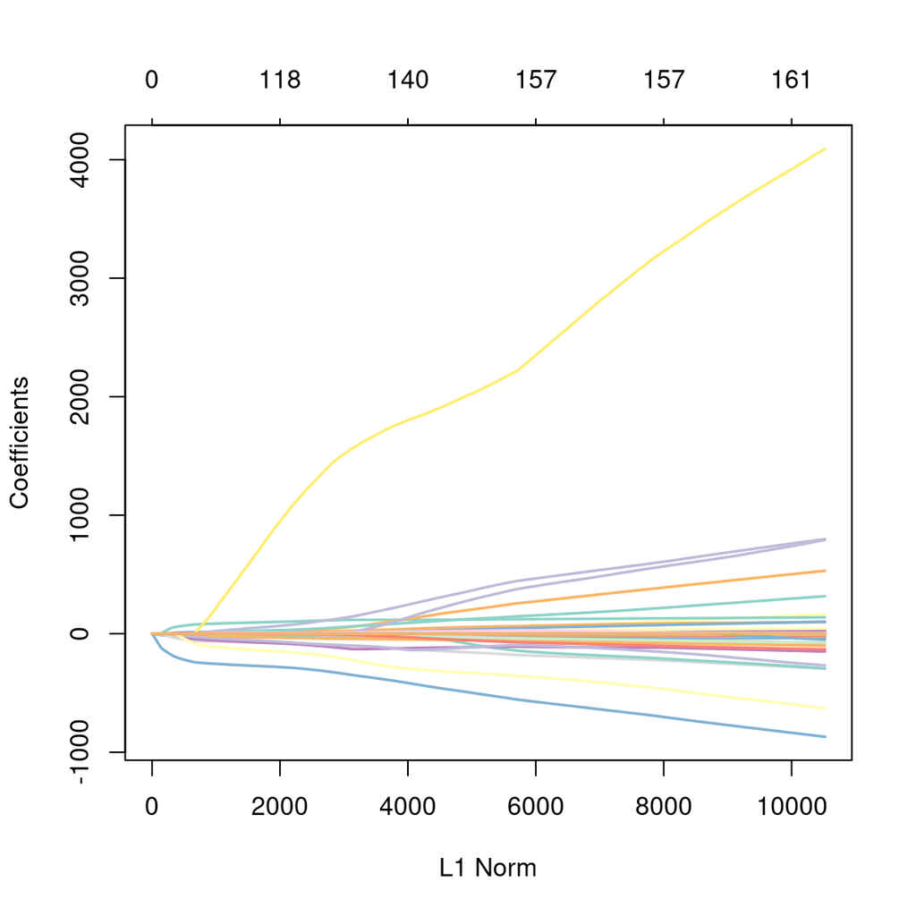

```r
plot(glmfit, xvar = "norm", col = RColorBrewer::brewer.pal(12, "Set3"), lwd = sqrt(3))
```

What is the x-axis? What are the different lines? Check the `plot.glmnet` documentation and look at different `xvar` options.

In particular, we note that as the penalty $\lambda$ increases, the L1 Norm of the coefficients ($\sum |\beta_i|$) shrinks. `glmnet` only shrinks the coefficients corresponding to the variables and not the intercept, however for simplicity our computations (and questions) below also include the intercept (the first coefficient returned from `coef`).

For example as above let’s see what fitted coefficients we got for $\lambda = 0.04$:

```r
# matrix of coefficients with given lambda
fitted_beta = coef(glmfit, s=0.04)
dim(fitted_beta)
```

```
[1] 1506    1
```

```r
# L1 norm of coefficients
sum(abs(fitted_beta))
```

```
[1] 1205.046
```

Let’s try with larger $\lambda$:

```r
# L1 norm of coefficients with given lambda
sum(abs(coef(glmfit, s=0.1)))
```

```
[1] 40.62017
```

**Question**

For how many different values of $\lambda$ did `glmnet` fit the model using settings as above? Inspect the `glmfit` object.

```r
length(glmfit$lambda)
```

[1] 100

**Question**

For each of the values of $\lambda$ in the object above, calculate the L1 Norm (as we did above for two values of $\lambda$). Which $\lambda$ most closely corresponds to a L1 norm 6000?

```r
# matrix of coefficients for all lambda
fitted_beta <- coef(glmfit)
dim(fitted_beta)
```

[1] 1506 100

```r
# L1 norm of coefficients for each lambda
L1Norm <- colSums(abs(fitted_beta))

# which L1 norm is clisest to 6000
idx_L1Norm_6k <- which.min(abs(L1Norm - 6000))
lambda_6k <- glmfit$lambda[idx_L1Norm_6k]
lambda_6k
```

[1] 0.00946895

**Question:**

How many non-zero coefficients do you get for the $\lambda$ that you found in the previous question?

```r
non0_coeff <- abs(coef(glmfit, s=lambda_6k)) > 0
sum(non0_coeff)
```

[1] 157

To choose the best regularization parameter $\lambda$, we use cross-validation. `cv.glmnet()` implements this.

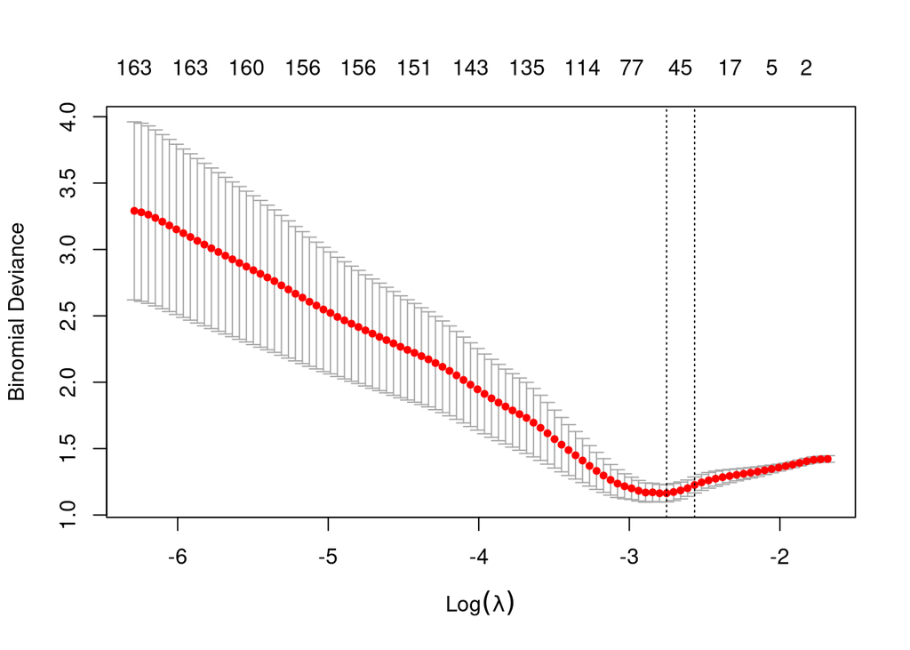

```r
set.seed(0xdada2)
cvglmfit = cv.glmnet(
  x = t(exprs(zellerNC)),
  y = factor(zellerNC$disease),
  family = "binomial"
)

# deviation for different lambdas
plot(cvglmfit)
```

We can access the optimal value with:

```r
cvglmfit$lambda.min
```

```
[1] 0.06376534
```

As this value results from finding a minimum in an estimated curve, it turns out that it is often too small, i.e., that the implied penalization is too weak. A heuristic recommended by the authors of the `glmnet` package is to use a somewhat larger value instead, namely the largest value of $\lambda$ such that the performance measure is within 1 standard error of the minimum.

```r
cvglmfit$lambda.1se
```

```
[1] 0.07680558
```

**Question**

How does the confusion table look like for $\lambda$ = `lambda.1se`? Report the top left element of the confusion table (i.e. number of correctly classified cancer samples). Hint: Use function `predict`.

```r
# predictions
preds_1se <- predict(
  glmfit,
  newx = t(exprs(zellerNC)),
  s = cvglmfit$lambda.1se,
  type = "class"
)

# confusion table
table(predicted = preds_1se, truth = zellerNC$disease)
```

```
         truth
predicted cancer  n
   cancer     39  4
   n          14 57
```

**Question**

What features drive the classification (at $\lambda$ = `lambda.1se` chosen by cross-validation with the 1 standard error rule)? Report the top one (the one with the largest absolute value of its coefficient).

```r
# coefficients with selected beta
coeffs <- coef(glmfit, s=cvglmfit$lambda.1se)
# top coefficient
idx_largest_beta <- which.max(abs(as.numeric(coeffs)))
rownames(coef(glmfit))[idx_largest_beta]
```

[1] “k__Bacteria|p__Candidatus_Saccharibacteria|c__Candidatus_Saccharibacteria_noname|o__Candidatus_Saccharibacteria_noname|f__Candidatus_Saccharibacteria_noname|g__Candidatus_Saccharibacteria_noname|s__candidate_division_TM7_single_cell_isolate_TM7b”

## Method hacking

The gold standard remains validation on truly unseen data. In addition, it is never a bad thing if the classifier is not a black box but can be interpreted in terms of domain knowledge. Finally, report not just summary statistics, such as misclassification rates, but lay open the complete computational workflow, so that anyone (including your future self) can convince themselves of the robustness of the result or of the influence of the preprocessing, model selection and tuning choices.

After this word of caution, have a look at the `caret` package. It contains [a large number of machine learning methods](https://topepo.github.io/caret/available-models.html) with an common interface.

```r
library("caret")
caretMethods = names(getModelInfo())
head(caretMethods, 8)
```

```
[1] "ada"         "AdaBag"      "AdaBoost.M1" "adaboost"    "amdai"
[6] "ANFIS"       "avNNet"      "awnb"
```

**Question**

How many methods does `caret` currently include?

```r
length(caretMethods)
```

[1] 239